# Targeting A Housing Subsidy

Jingmiao Fei

2024-10-31

# 1. Introduction

The Emil City Department of Housing and Community Development (HCD) has long struggled with low participation in its home repair tax credit program, largely due to a random outreach approach that may not effectively reach homeowners likely to benefit. To address this, we analyze past client-level data and develop a predictive model for targeted outreach. This analysis will use logistic regression to classify homeowners by their likelihood of utilizing the tax credit, aiming to focus outreach resources more effectively. We also use a cost-benefit analysis to help HCD quantify the estimated revenue and optimize its engagement strategy.

```r
rm(list=ls())

options(scipen=10000000)

library(tidyverse)
library(kableExtra)
library(caret)
library(knitr)
library(pscl)
library(plotROC)
library(pROC)
library(lubridate)
library(scales)
library(rstatix)
library(ggpubr)
library(crosstable)
library(ggcorrplot)
library(rsample)
library(gridExtra)
library(scales)

palette5 <- c("darkblue", "lightblue", "yellow", "lightcoral", "darkred")
palette4 <- c("lightblue","orange","lightcoral","yellow")
palette3 <- c("darkblue", "yellow", "darkred")
palette2 <- c("lightblue","lightcoral")

# Functions and data directory

root.dir = "https://raw.githubusercontent.com/urbanSpatial/Public-Policy-Analytics-Landing/master/DATA/"
source("https://raw.githubusercontent.com/urbanSpatial/Public-Policy-Analytics-Landing/master/functions.r")
```

# 2. Exploratory analysis

```r
# load dataset
housing <- read.csv("housingSubsidy.csv")
```

## 2.1 multi-correlation test

A correlation plot is used to evaluate relations and multicollinearity between numeric variables. The following plot indicates a high correlation `(the absolute r-value is 0.8 or greater)` between predicting categories:

1. Unemployment Rate and Consolidated Price Index
2. Unemployment Rate and Amount Spent on Repairs
3. Inflation Rate and Amount Spent on Repairs

Therefore, Unemployment Rate and Inflation Rate are be removed to improve the final model’s performance.

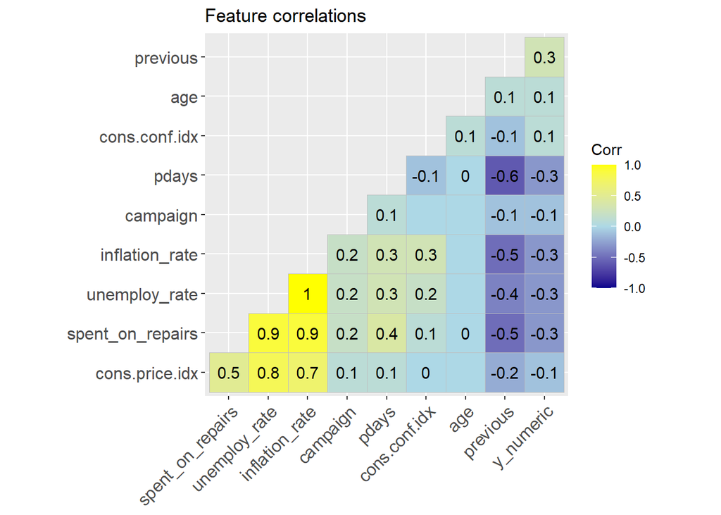

```r
# correlation matrix
corr <- round(cor(housing %>% select(where(is.numeric))%>%select(-X)), 1)
p.mat <- cor_pmat(housing %>% select(where(is.numeric))%>%select(-X))

ggcorrplot(corr, p.mat = p.mat, hc.order = TRUE,
    type = "lower", insig = "blank",
    ggtheme = ggplot2::theme_gray,
    colors = palette5, title = "Feature correlations", lab = TRUE)
```

## 2.2 T-test

Here we use T-test to examine the relationship between numeric variables and the dependent variable. Indicators with a p-value less than 0.05 are considered as a meaningful predictor.

```r
ttest <- housing %>%
  select(-X)%>%
  pivot_longer(cols = where(is.numeric), names_to = "variable", values_to = "value") %>%
  filter(variable != "y_numeric") %>%
  group_by(variable) %>%
  rstatix::t_test(value ~ y) %>%
  adjust_pvalue(method = "BH") %>%
  add_significance() %>%
  select(variable,
         p,
         p.adj,
         p.adj.signif)

ttest %>%
  kbl() %>%
  kable_minimal()
```

| variable | p | p.adj | p.adj.signif |
| --- | --- | --- | --- |
| age | 0.0021600 | 0.0024300 | ** |
| campaign | 0.0000000 | 0.0000000 | **** |
| cons.conf.idx | 0.0057700 | 0.0057700 | ** |
| cons.price.idx | 0.0000001 | 0.0000001 | **** |
| inflation_rate | 0.0000000 | 0.0000000 | **** |
| pdays | 0.0000000 | 0.0000000 | **** |
| previous | 0.0000000 | 0.0000000 | **** |
| spent_on_repairs | 0.0000000 | 0.0000000 | **** |
| unemploy_rate | 0.0000000 | 0.0000000 | **** |

## 2.3 chi-squared test

The chi-square test is typically used to examine the relationship between categorical independent and dependent variables. Based on these tests, we will drop 3 predictors with p-value more than 0.05: “mortgage”, “taxbill_in_phl” and day_of_week” in feature engineering.

```r
cat_vars <- colnames(housing %>% select(where(is.character)))

crosstable(housing,
           cat_vars,
           by=y,
           total="both",
           percent_pattern="{n} ({p_row}/{p_col})",
           percent_digits=0,
           test = TRUE) %>%
  as_flextable()
```

| label | variable | y no | y yes | Total | test |  |  |  |  |  |  |
| --- | --- | --- | --- | --- | --- | --- | --- | --- | --- | --- | --- |
| job | admin. | 879 (87%/24%) | 133 (13%/29%) |  |  | 1012 (25%) | p value: <0.0001 (Fisher's Exact Test for Count Data with simulated p-value (based on 100000 replicates)) |  |  |  |  |
|  | blue-collar | 823 (93%/22%) | 61 (7%/14%) | 884 (21%) |  |  |  |  |  |  |  |
|  | entrepreneur | 140 (95%/4%) | 8 (5%/2%) | 148 (4%) |  |  |  |  |  |  |  |
|  | housemaid | 99 (90%/3%) | 11 (10%/2%) | 110 (3%) |  |  |  |  |  |  |  |
|  | management | 294 (91%/8%) | 30 (9%/7%) | 324 (8%) |  |  |  |  |  |  |  |
|  | retired | 128 (77%/3%) | 38 (23%/8%) | 166 (4%) |  |  |  |  |  |  |  |
|  | self-employed | 146 (92%/4%) | 13 (8%/3%) | 159 (4%) |  |  |  |  |  |  |  |
|  | services | 358 (91%/10%) | 35 (9%/8%) | 393 (10%) |  |  |  |  |  |  |  |
|  | student | 63 (77%/2%) | 19 (23%/4%) | 82 (2%) |  |  |  |  |  |  |  |
|  | technician | 611 (88%/17%) | 80 (12%/18%) | 691 (17%) |  |  |  |  |  |  |  |
|  | unemployed | 92 (83%/3%) | 19 (17%/4%) | 111 (3%) |  |  |  |  |  |  |  |
|  | unknown | 35 (90%/1%) | 4 (10%/1%) | 39 (1%) |  |  |  |  |  |  |  |
|  | Total | 3668 (89%) | 451 (11%) | 4119 (100%) |  |  |  |  |  |  |  |
| marital | divorced | 403 (90%/11%) | 43 (10%/10%) | 446 (11%) | p value: 0.0165 (Fisher's Exact Test for Count Data) |  |  |  |  |  |  |
|  | married | 2257 (90%/62%) | 252 (10%/56%) | 2509 (61%) |  |  |  |  |  |  |  |
|  | single | 998 (87%/27%) | 155 (13%/34%) | 1153 (28%) |  |  |  |  |  |  |  |
|  | unknown | 10 (91%/0.3%) | 1 (9%/0.2%) | 11 (0.3%) |  |  |  |  |  |  |  |
|  | Total | 3668 (89%) | 451 (11%) | 4119 (100%) |  |  |  |  |  |  |  |
| education | basic.4y | 391 (91%/11%) | 38 (9%/8%) | 429 (10%) |  | p value: 0.0014 (Fisher's Exact Test for Count Data with simulated p-value (based on 100000 replicates)) |  |  |  |  |  |
|  | basic.6y | 211 (93%/6%) | 17 (7%/4%) | 228 (6%) |  |  |  |  |  |  |  |
|  | basic.9y | 531 (93%/14%) | 43 (7%/10%) | 574 (14%) |  |  |  |  |  |  |  |
|  | high.school | 824 (89%/22%) | 97 (11%/22%) | 921 (22%) |  |  |  |  |  |  |  |
|  | illiterate | 1 (100%/0.03%) | 0 (0%/0%) | 1 (0.02%) |  |  |  |  |  |  |  |
|  | professional.course | 470 (88%/13%) | 65 (12%/14%) | 535 (13%) |  |  |  |  |  |  |  |
|  | university.degree | 1099 (87%/30%) | 165 (13%/37%) | 1264 (31%) |  |  |  |  |  |  |  |
|  | unknown | 141 (84%/4%) | 26 (16%/6%) | 167 (4%) |  |  |  |  |  |  |  |
|  | Total | 3668 (89%) | 451 (11%) | 4119 (100%) |  |  |  |  |  |  |  |
| taxLien | no | 2913 (88%/79%) | 402 (12%/89%) | 3315 (80%) |  |  |  | p value: <0.0001 (Fisher's Exact Test for Count Data) |  |  |  |
|  | unknown | 754 (94%/21%) | 49 (6%/11%) | 803 (19%) |  |  |  |  |  |  |  |
|  | yes | 1 (100%/0.03%) | 0 (0%/0%) | 1 (0.02%) |  |  |  |  |  |  |  |
|  | Total | 3668 (89%) | 451 (11%) | 4119 (100%) |  |  |  |  |  |  |  |
| mortgage | no | 1637 (89%/45%) | 202 (11%/45%) | 1839 (45%) |  |  |  |  | p value: 0.7307 (Pearson's Chi-squared test) |  |  |
|  | unknown | 96 (91%/3%) | 9 (9%/2%) | 105 (3%) |  |  |  |  |  |  |  |
|  | yes | 1935 (89%/53%) | 240 (11%/53%) | 2175 (53%) |  |  |  |  |  |  |  |
|  | Total | 3668 (89%) | 451 (11%) | 4119 (100%) |  |  |  |  |  |  |  |
| taxbill_in_phl | no | 693 (90%/19%) | 77 (10%/17%) | 770 (19%) |  |  |  |  |  | p value: 0.3495 (Pearson's Chi-squared test) |  |
|  | yes | 2975 (89%/81%) | 374 (11%/83%) | 3349 (81%) |  |  |  |  |  |  |  |
|  | Total | 3668 (89%) | 451 (11%) | 4119 (100%) |  |  |  |  |  |  |  |
| contact | cellular | 2277 (86%/62%) | 375 (14%/83%) | 2652 (64%) | p value: <0.0001 (Pearson's Chi-squared test) |  |  |  |  |  |  |
|  | telephone | 1391 (95%/38%) | 76 (5%/17%) | 1467 (36%) |  |  |  |  |  |  |  |
|  | Total | 3668 (89%) | 451 (11%) | 4119 (100%) |  |  |  |  |  |  |  |
| month | apr | 179 (83%/5%) | 36 (17%/8%) | 215 (5%) |  |  |  |  |  |  | p value: <0.0001 (Fisher's Exact Test for Count Data with simulated p-value (based on 100000 replicates)) |
|  | aug | 572 (90%/16%) | 64 (10%/14%) | 636 (15%) |  |  |  |  |  |  |  |
|  | dec | 10 (45%/0.3%) | 12 (55%/3%) | 22 (1%) |  |  |  |  |  |  |  |
|  | jul | 652 (92%/18%) | 59 (8%/13%) | 711 (17%) |  |  |  |  |  |  |  |
|  | jun | 462 (87%/13%) | 68 (13%/15%) | 530 (13%) |  |  |  |  |  |  |  |
|  | mar | 20 (42%/1%) | 28 (58%/6%) | 48 (1%) |  |  |  |  |  |  |  |
|  | may | 1288 (93%/35%) | 90 (7%/20%) | 1378 (33%) |  |  |  |  |  |  |  |
|  | nov | 403 (90%/11%) | 43 (10%/10%) | 446 (11%) |  |  |  |  |  |  |  |
|  | oct | 44 (64%/1%) | 25 (36%/6%) | 69 (2%) |  |  |  |  |  |  |  |
|  | sep | 38 (59%/1%) | 26 (41%/6%) | 64 (2%) |  |  |  |  |  |  |  |
|  | Total | 3668 (89%) | 451 (11%) | 4119 (100%) |  |  |  |  |  |  |  |
| day_of_week | fri | 685 (89%/19%) | 83 (11%/18%) | 768 (19%) |  |  |  | p value: 0.9723 (Pearson's Chi-squared test) |  |  |  |
|  | mon | 757 (89%/21%) | 98 (11%/22%) | 855 (21%) |  |  |  |  |  |  |  |
|  | thu | 764 (89%/21%) | 96 (11%/21%) | 860 (21%) |  |  |  |  |  |  |  |
|  | tue | 750 (89%/20%) | 91 (11%/20%) | 841 (20%) |  |  |  |  |  |  |  |
|  | wed | 712 (90%/19%) | 83 (10%/18%) | 795 (19%) |  |  |  |  |  |  |  |
|  | Total | 3668 (89%) | 451 (11%) | 4119 (100%) |  |  |  |  |  |  |  |
| poutcome | failure | 387 (85%/11%) | 67 (15%/15%) | 454 (11%) | p value: <0.0001 (Pearson's Chi-squared test) |  |  |  |  |  |  |
|  | nonexistent | 3231 (92%/88%) | 292 (8%/65%) | 3523 (86%) |  |  |  |  |  |  |  |
|  | success | 50 (35%/1%) | 92 (65%/20%) | 142 (3%) |  |  |  |  |  |  |  |
|  | Total | 3668 (89%) | 451 (11%) | 4119 (100%) |  |  |  |  |  |  |  |

## 2.4 Visualization Charts for Continuous and Categorical Outcomes

### 2.4.1 Continuous Outcomes

Key Findings:

1. The “Campaign” feature indicates the frequency of contacts made during the tax credit program. Analysis reveals that individuals who received more contacts throughout the program are less likely to utilize the tax credit.
2. The “Previous” feature measures the number of contacts made with individuals before the tax credit program began. Unlike the first finding, those who were contacted more often prior to the program are more likely to take advantage of the tax credit than those with fewer prior interactions. This suggests that public awareness leading up to the program may significantly influence participation.
3. The inflation features shows that there seems to be a less likelihood of taking tax credit when the inflation rate is high.
4. Finally, the data shows that acceptance of the tax credit tends to be higher during periods of low unemployment (when the unemployment rate is negative). This implies that tax credits are more appealing in a strong economy, as individuals may be more willing to seek external resources for home purchases.

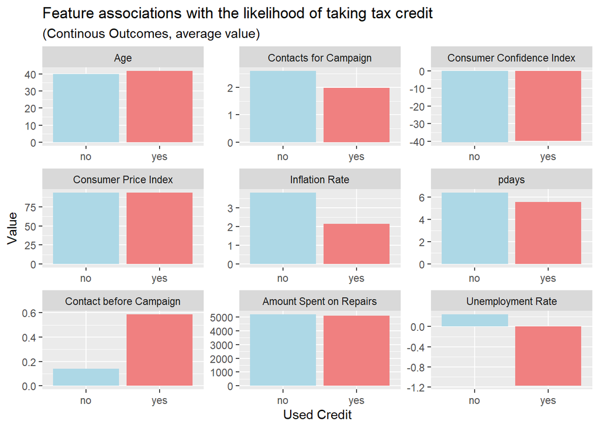

```r
# Continuous Outcomes Visualization

housing %>%
  dplyr::select(y, where(is.numeric), -X, -y_numeric) %>%
  gather(Variable, value, -y) %>%
  filter(!(Variable == "pdays" & value == 999)) %>%
    ggplot(aes(y, value, fill=y)) +
      geom_bar(position = "dodge", stat = "summary", fun.y = "mean") +
      facet_wrap(~Variable, scales = "free", ncol=3, labeller = labeller(Variable = c(
                     `age` = "Age",
                     `previous` = "Contact before Campaign",
                     `unemploy_rate` = "Unemployment Rate",
                     `cons.price.idx` = "Consumer Price Index",
                     `cons.conf.idx` = "Consumer Confidence Index",
                     `campaign` = "Contacts for Campaign",
                     `inflation_rate` = "Inflation Rate",
                     `spent_on_repairs` = "Amount Spent on Repairs"))) +
      scale_fill_manual(values = palette2) +
      labs(x="Used Credit", y="Value",
           title = "Feature associations with the likelihood of taking tax credit",
           subtitle = "(Continous Outcomes, average value)")+
      theme(legend.position = "none")
```

To gain a deeper insight into the distribution characteristics of these continuous variables and to facilitate comparisons among numeric features with varying scales, a density plot has been generated. This visualization uncovers surprising differences in the distributions of the Consumer Confidence Index, Consumer Price Index, and Amount Spent on Repairs between homeowners who accepted the tax credit and those who did not.

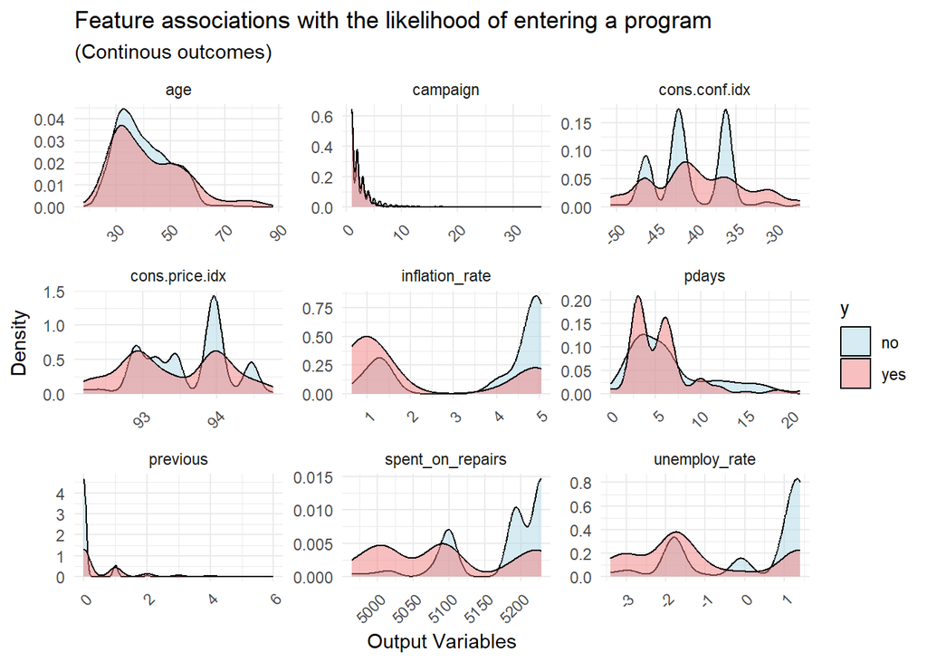

```r
hmm2 <- housing %>%
  pivot_longer(cols = where(is.numeric), names_to = "variable", values_to = "value") %>%
  filter(variable != "y_numeric", variable != "X")%>%
  filter(!(variable == "pdays" & value == 999))

ggplot(hmm2) +
  geom_density(aes(x = value, fill = y), alpha = 0.5) +
  facet_wrap(~variable, scales = "free") +
  scale_fill_manual(values = palette2) +
  labs(x="Output Variables", y="Density",
         title = "Feature associations with the likelihood of entering a program",
         subtitle = "(Continous outcomes)") +
  theme_minimal()+
  theme(axis.text.x = element_text(hjust = 1, angle = 45))
```

### 2.4.2 Categorical Outcomes

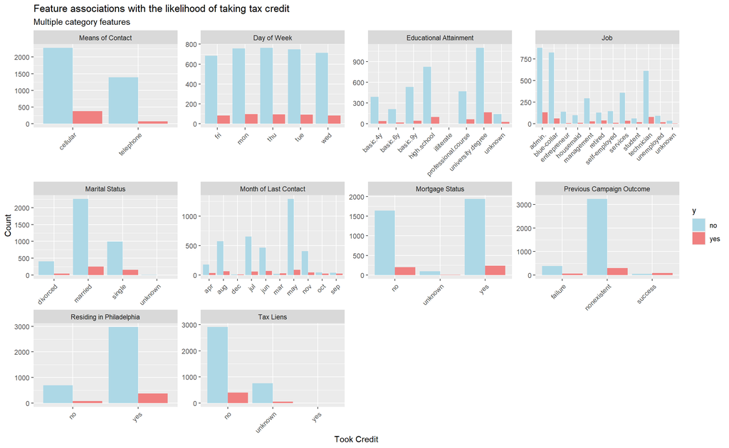

```r
# Categorical Outcomes Visualization

housing %>%
  select(where(is.character))%>%
  gather(Variable, value, -y) %>%
  count(Variable, value, y) %>%
  ggplot(aes(value, n, fill = y)) +
    geom_bar(position = "dodge", stat="identity") +
    facet_wrap(~Variable, scales="free", ncol=4,
                   labeller= labeller(Variable = c(
                     `contact` = "Means of Contact",
                     `day_of_week` = "Day of Week",
                     `education` = "Educational Attainment",
                     `pdays` = "Days Elapsed After Contact",
                     `job` = "Job",
                     `marital` = "Marital Status",
                     `month` = "Month of Last Contact",
                     `mortgage` = "Mortgage Status",
                     `poutcome` = "Previous Campaign Outcome",
                     `taxbill_in_phl` = "Residing in Philadelphia",
                     `taxLien` = "Tax Liens"))) +
    scale_fill_manual(values = palette2) +
    labs(x="Took Credit", y="Count",
         title = "Feature associations with the likelihood of taking tax credit",
         subtitle = "Multiple category features") +
    theme(axis.text.x = element_text(angle=45, hjust=1))
```

# 3. Feature Engineering

We found that the “tax lien” feature in the original housing data has only one record of “yes”, which will cause error in the regression analysis. So we combined “unknown” and “yes” as “yes or unknown”.

To improve the model’s predictive accuracy, we created new fields to capture homeowner characteristics in greater detail:

1. Quarter : Months are categorized into yearly quarters, namely Quarter 1, Quarter 2, Quarter 3, and Quarter 4.
2. Education Status: Educational levels are restructured to simplify the categories, as those with basic (“basic” and “illiterate”), secondary (high.school” and “professional.course) and higher (”university.degree”) level education.
3. Last Contact: The duration since a homeowner has been last approached is transformed from days to weeks.
4. Employment : This feature has been refined to reflect whether an individual is unemployed, blue collar, white collar or self-employed.
5. Age group: The age has been categorized into four levels: under 25, 26~45, 46 ~70 and above 70.
6. Marriage: The marital status has been refined as married and others.

These adjustments aim to provide more comprehensive and informative data for the predictive model.

```r
housing <-
  housing %>%
  mutate(taxLien = case_when(
    taxLien == "unknown" | taxLien == "yes" ~ "yes or unknown",
    TRUE  ~ "no"))
```

```r
housing_new <- housing%>%
  select(-unemploy_rate, -inflation_rate, - mortgage, -taxbill_in_phl, -day_of_week, -X)%>%
# Quarter
  mutate(month_special = case_when(
    month == "jan" | month == "feb"| month == "mar" ~ "Quarter 1",
    month == "apr" |month == "may" | month == "jun" ~ "Quarter 2",
    month == "jul" |month == "aug" | month == "sep" ~ "Quarter 3",
    month == "oct" | month == "nov"| month == "dec" ~ "Quarter 4"))%>%
# Education
  mutate(EducationStatus = case_when(
    education %in% c("basic.9y", "basic.6y", "basic.4y", "illiterate")   ~ "basic education",
    education %in% c("high.school", "professional.course")  ~ "secondary education",
    education == "university.degree"  ~ "higher education",
    education == "unknown" ~ "unknown"))%>%
# Prior Contact
  mutate(LastContact = case_when(pdays == 999 ~ "No Contact",
                                 pdays <= 7 ~ "1 Week",
                                 pdays > 7 & pdays <= 14 ~ "2 Weeks",
                                 pdays > 14 & pdays <= 21 ~ "3 Weeks"))%>%
# Employment
  mutate(Employment = case_when(job %in% c("student", "unemployed", "retired") ~ "unemployed",
                                job %in% c("blue-collar", "services","housemaid") ~ "bluecollar_services",
                                job %in% c("admin.", "management","technican","entrepreneur") ~ "whitecollar",
                                job == "self-employed" ~ "self-employed",
                                job == "unknown" ~ "unknown"))%>%
# Age Groups
  mutate(AgeGroup = case_when(
    age <= 25  ~ "Under 25",
    age >= 26 & age < 45  ~ "26-45",
    age >= 45 & age <= 70  ~ "45-70",
    TRUE ~ "Above 70"))%>%
# marital
  mutate(Marriage = case_when(marital =="married" ~ "married", TRUE ~ "other"))%>%
  select(-month, -education, -pdays, -previous, -age, -job, -marital) %>%
  na.omit()
```

To assess predictive capacity, both base categories as well as new categories are tested using chi-square tests. It is observed seen that all engineered variables are likely to be significant predictors (p<0.05).

```r
cat_vars <- colnames(housing_new %>% select(where(is.character)))

crosstable(housing_new,
           cat_vars,
           by=y,
           total="both",
           percent_pattern="{n} ({p_row}/{p_col})",
           percent_digits=0,
           test = TRUE) %>%
  as_flextable()
```

| label | variable | y no | y yes | Total | test |  |  |  |  |  |
| --- | --- | --- | --- | --- | --- | --- | --- | --- | --- | --- |
| taxLien | no | 2380 (88%/78%) | 329 (12%/89%) |  |  | 2709 (79%) | p value: <0.0001 (Pearson's Chi-squared test) |  |  |  |
|  | yes or unknown | 677 (94%/22%) | 42 (6%/11%) | 719 (21%) |  |  |  |  |  |  |
|  | Total | 3057 (89%) | 371 (11%) | 3428 (100%) |  |  |  |  |  |  |
| contact | cellular | 1885 (86%/62%) | 306 (14%/82%) | 2191 (64%) | p value: <0.0001 (Pearson's Chi-squared test) |  |  |  |  |  |
|  | telephone | 1172 (95%/38%) | 65 (5%/18%) | 1237 (36%) |  |  |  |  |  |  |
|  | Total | 3057 (89%) | 371 (11%) | 3428 (100%) |  |  |  |  |  |  |
| poutcome | failure | 333 (86%/11%) | 52 (14%/14%) | 385 (11%) |  | p value: <0.0001 (Pearson's Chi-squared test) |  |  |  |  |
|  | nonexistent | 2680 (92%/88%) | 241 (8%/65%) | 2921 (85%) |  |  |  |  |  |  |
|  | success | 44 (36%/1%) | 78 (64%/21%) | 122 (4%) |  |  |  |  |  |  |
|  | Total | 3057 (89%) | 371 (11%) | 3428 (100%) |  |  |  |  |  |  |
| month_special | Quarter 1 | 12 (33%/0.4%) | 24 (67%/6%) | 36 (1%) |  |  |  | p value: <0.0001 (Fisher's Exact Test for Count Data) |  |  |
|  | Quarter 2 | 1651 (91%/54%) | 164 (9%/44%) | 1815 (53%) |  |  |  |  |  |  |
|  | Quarter 3 | 999 (89%/33%) | 120 (11%/32%) | 1119 (33%) |  |  |  |  |  |  |
|  | Quarter 4 | 395 (86%/13%) | 63 (14%/17%) | 458 (13%) |  |  |  |  |  |  |
|  | Total | 3057 (89%) | 371 (11%) | 3428 (100%) |  |  |  |  |  |  |
| EducationStatus | basic education | 1084 (92%/35%) | 97 (8%/26%) | 1181 (34%) | p value: 0.0005 (Pearson's Chi-squared test) |  |  |  |  |  |
|  | higher education | 933 (87%/31%) | 135 (13%/36%) | 1068 (31%) |  |  |  |  |  |  |
|  | secondary education | 917 (89%/30%) | 114 (11%/31%) | 1031 (30%) |  |  |  |  |  |  |
|  | unknown | 123 (83%/4%) | 25 (17%/7%) | 148 (4%) |  |  |  |  |  |  |
|  | Total | 3057 (89%) | 371 (11%) | 3428 (100%) |  |  |  |  |  |  |
| LastContact | 1 Week | 40 (35%/1%) | 74 (65%/20%) | 114 (3%) |  |  |  |  | p value: <0.0001 (Fisher's Exact Test for Count Data) |  |
|  | 2 Weeks | 8 (50%/0.3%) | 8 (50%/2%) | 16 (0.5%) |  |  |  |  |  |  |
|  | 3 Weeks | 4 (67%/0.1%) | 2 (33%/1%) | 6 (0.2%) |  |  |  |  |  |  |
|  | No Contact | 3005 (91%/98%) | 287 (9%/77%) | 3292 (96%) |  |  |  |  |  |  |
|  | Total | 3057 (89%) | 371 (11%) | 3428 (100%) |  |  |  |  |  |  |
| Employment | bluecollar_services | 1280 (92%/42%) | 107 (8%/29%) | 1387 (40%) |  |  | p value: <0.0001 (Fisher's Exact Test for Count Data with simulated p-value (based on 100000 replicates)) |  |  |  |
|  | self-employed | 146 (92%/5%) | 13 (8%/4%) | 159 (5%) |  |  |  |  |  |  |
|  | unemployed | 283 (79%/9%) | 76 (21%/20%) | 359 (10%) |  |  |  |  |  |  |
|  | unknown | 35 (90%/1%) | 4 (10%/1%) | 39 (1%) |  |  |  |  |  |  |
|  | whitecollar | 1313 (88%/43%) | 171 (12%/46%) | 1484 (43%) |  |  |  |  |  |  |
|  | Total | 3057 (89%) | 371 (11%) | 3428 (100%) |  |  |  |  |  |  |
| AgeGroup | 26-45 | 1942 (90%/64%) | 206 (10%/56%) | 2148 (63%) |  | p value: <0.0001 (Fisher's Exact Test for Count Data) |  |  |  |  |
|  | 45-70 | 975 (88%/32%) | 130 (12%/35%) | 1105 (32%) |  |  |  |  |  |  |
|  | Above 70 | 18 (49%/1%) | 19 (51%/5%) | 37 (1%) |  |  |  |  |  |  |
|  | Under 25 | 122 (88%/4%) | 16 (12%/4%) | 138 (4%) |  |  |  |  |  |  |
|  | Total | 3057 (89%) | 371 (11%) | 3428 (100%) |  |  |  |  |  |  |
| Marriage | married | 1914 (90%/63%) | 211 (10%/57%) | 2125 (62%) |  |  |  |  |  | p value: 0.0316 (Pearson's Chi-squared test) |
|  | other | 1143 (88%/37%) | 160 (12%/43%) | 1303 (38%) |  |  |  |  |  |  |
|  | Total | 3057 (89%) | 371 (11%) | 3428 (100%) |  |  |  |  |  |  |

# 4. Model Builind

Two regression analyses are performed: one using all original features without engineered variables, termed the `kitchen sink model`, and another using a combination of selected original features and engineered variables, referred to as the `engineered model`. The kitchen sink model provides a baseline for assessing the current performance and predictive strength of the model, while the engineered model aims to enhance predictive accuracy.

For both models, data is divided into training and testing sets with a 65:35 ratio. The training set enables the model to learn the relationships between input features and the target variable, while the testing set allows us to evaluate how well it might generalize to new data.

## 4.1 Kitchen Sink Model

### 4.1.1 Model Summary

```r
# Split Data  - Kitchen Sink - Base Model

set.seed(3)

kitchenSink_base <- housing %>%
  select(-X)%>%
  initial_split(prop = 0.65, strata = y)
kitchenSink_Train <- training(kitchenSink_base)
kitchenSink_Test  <-  testing(kitchenSink_base)

# Regression - Kitchen Sink - Base Model

kitchenSink_reg_base <- glm(y_numeric ~ ., data = kitchenSink_Train%>%select(-y), family = binomial(link = "logit"))

print(summary(kitchenSink_reg_base))
```

```
##
## Call:
## glm(formula = y_numeric ~ ., family = binomial(link = "logit"),
##     data = kitchenSink_Train %>% select(-y))
##
## Coefficients:
##                                  Estimate   Std. Error z value Pr(>|z|)
## (Intercept)                  -224.6270224  130.8520063  -1.717  0.08604 .
## age                             0.0200011    0.0083695   2.390  0.01686 *
## jobblue-collar                 -0.2323833    0.2791547  -0.832  0.40515
## jobentrepreneur                -0.9565802    0.5513127  -1.735  0.08272 .
## jobhousemaid                   -0.0950196    0.4803501  -0.198  0.84319
## jobmanagement                  -0.7209197    0.3155988  -2.284  0.02235 *
## jobretired                     -0.5449148    0.3858183  -1.412  0.15784
## jobself-employed               -0.7209029    0.4168511  -1.729  0.08374 .
## jobservices                    -0.6363281    0.3220334  -1.976  0.04816 *
## jobstudent                      0.2712142    0.4517188   0.600  0.54824
## jobtechnician                  -0.0271477    0.2360705  -0.115  0.90845
## jobunemployed                   0.1942047    0.3869979   0.502  0.61579
## jobunknown                     -0.0635066    0.8061861  -0.079  0.93721
## maritalmarried                  0.0614137    0.2429193   0.253  0.80041
## maritalsingle                   0.0449526    0.2826534   0.159  0.87364
## maritalunknown                  0.4736009    1.2541293   0.378  0.70570
## educationbasic.6y               0.4742905    0.4096971   1.158  0.24700
## educationbasic.9y               0.3121802    0.3509960   0.889  0.37378
## educationhigh.school            0.3750402    0.3354481   1.118  0.26356
## educationilliterate           -10.6803086  324.7442168  -0.033  0.97376
## educationprofessional.course    0.5818050    0.3563273   1.633  0.10251
## educationuniversity.degree      0.4814763    0.3351456   1.437  0.15083
## educationunknown                0.1981585    0.4483817   0.442  0.65853
## taxLienyes or unknown           0.0356006    0.2139590   0.166  0.86785
## mortgageunknown                -0.7374280    0.6023976  -1.224  0.22089
## mortgageyes                    -0.1502254    0.1448624  -1.037  0.29973
## taxbill_in_phlyes               0.0233118    0.1905802   0.122  0.90265
## contacttelephone               -0.9399485    0.2885220  -3.258  0.00112 **
## monthaug                       -0.2730262    0.4514694  -0.605  0.54534
## monthdec                        0.9001675    0.6655152   1.353  0.17619
## monthjul                       -0.0956177    0.3622389  -0.264  0.79181
## monthjun                       -0.0497620    0.4630236  -0.107  0.91441
## monthmar                        1.4510575    0.5920736   2.451  0.01425 *
```

[output cut: 13 more lines]

```
## unemploy_rate                  -0.3847595    0.5099880  -0.754  0.45058
## cons.price.idx                  1.7026570    0.8699614   1.957  0.05033 .
## cons.conf.idx                   0.0883545    0.0291188   3.034  0.00241 **
## inflation_rate                 -0.9451996    0.4602678  -2.054  0.04002 *
## spent_on_repairs                0.0133261    0.0105139   1.267  0.20498
## ---
## Signif. codes:  0 '***' 0.001 '**' 0.01 '*' 0.05 '.' 0.1 ' ' 1
##
## (Dispersion parameter for binomial family taken to be 1)
##
##     Null deviance: 1849.1  on 2676  degrees of freedom
## Residual deviance: 1451.1  on 2626  degrees of freedom
## AIC: 1553.1
##
## Number of Fisher Scoring iterations: 11
```

The McFadden’s R-squared value between 0.2 to 0.4 are considered good model. Here, the kitchen sink model has a McFadden value of `0.215` indicating that it is a good model.

```r
pR2(kitchenSink_reg_base)
```

```
## fitting null model for pseudo-r2
```

```
##          llh      llhNull           G2     McFadden         r2ML         r2CU
## -725.5675846 -924.5440389  397.9529085    0.2152158    0.1381347    0.2769392
```

### 4.1.2 Confusion Matrix

```r
# Confusion Matrix - Kitchen Sink - Base Model

kitchenSink_Test_Prob <- data.frame(outcome = as.factor(kitchenSink_Test$y_numeric),
                        probs = predict(kitchenSink_reg_base, kitchenSink_Test, type = "response"))%>%
                        mutate(pred_outcome  = as.factor(ifelse(probs > 0.5 , 1, 0)))


print(caret::confusionMatrix(kitchenSink_Test_Prob$pred_outcome, kitchenSink_Test_Prob$outcome,
                       positive = "1"))
```

```
## Confusion Matrix and Statistics
##
##           Reference
## Prediction    0    1
##          0 1267  126
##          1   17   32
##
##                Accuracy : 0.9008
##                  95% CI : (0.8842, 0.9158)
##     No Information Rate : 0.8904
##     P-Value [Acc > NIR] : 0.1097
##
##                   Kappa : 0.2714
##
##  Mcnemar's Test P-Value : <0.0000000000000002
##
##             Sensitivity : 0.20253
##             Specificity : 0.98676
##          Pos Pred Value : 0.65306
##          Neg Pred Value : 0.90955
##              Prevalence : 0.10957
##          Detection Rate : 0.02219
##    Detection Prevalence : 0.03398
##       Balanced Accuracy : 0.59465
##
##        'Positive' Class : 1
##
```

### 4.1.3 ROC

```r
# ROC - Kitchen Sink - Base Model

ctrl <- trainControl(method = "cv", number = 100, classProbs=TRUE, summaryFunction=twoClassSummary)

cvFit_base <- train(y ~ .,
               data= kitchenSink_Train %>% dplyr::select(-y_numeric),
                method="glm",
                family="binomial",
                metric="ROC",
                trControl = ctrl)

cvFit_base
```

```
## Generalized Linear Model
##
## 2677 samples
##   19 predictor
##    2 classes: 'no', 'yes'
##
## No pre-processing
## Resampling: Cross-Validated (100 fold)
## Summary of sample sizes: 2650, 2651, 2650, 2650, 2651, 2650, ...
## Resampling results:
##
##   ROC        Sens       Spec
##   0.7563496  0.9823732  0.195
```

The AUC of kitchen sink model is 0.78, indicating that this is an acceptable model.

```r
# AUC - kitchen sink model

auc(kitchenSink_Test_Prob$outcome, kitchenSink_Test_Prob$probs)
```

```
## Area under the curve: 0.7827
```

## 4.2 Feature Engineered Model

### 4.2.1 Model Summary

```r
#Split Data - Engineered Model

set.seed(3)

housing_new_base <- initial_split(housing_new, prop = 0.65, strata = y)
housing_new_Train <- training(housing_new_base)
housing_new_Test  <-  testing(housing_new_base)
```

```r
# Regression - Engineered Model

housing_new_reg_base <- glm(y_numeric ~ ., data = housing_new_Train%>%select(-y), family = binomial(link = "logit"))

print(summary(housing_new_reg_base))
```

```
##
## Call:
## glm(formula = y_numeric ~ ., family = binomial(link = "logit"),
##     data = housing_new_Train %>% select(-y))
##
## Coefficients:
##                                     Estimate Std. Error z value
## (Intercept)                        37.251364  15.498960   2.403
## taxLienyes or unknown              -0.148304   0.247401  -0.599
## contacttelephone                   -0.726832   0.285273  -2.548
## campaign                           -0.074630   0.045556  -1.638
## poutcomenonexistent                 0.373449   0.239062   1.562
## poutcomesuccess                     0.859562   0.989886   0.868
## cons.price.idx                      0.119465   0.162044   0.737
## cons.conf.idx                       0.036218   0.019400   1.867
## spent_on_repairs                   -0.009059   0.001144  -7.918
## month_specialQuarter 2             -1.629941   0.541217  -3.012
## month_specialQuarter 3             -1.496015   0.564341  -2.651
## month_specialQuarter 4             -1.805193   0.568178  -3.177
## EducationStatushigher education     0.284656   0.252719   1.126
## EducationStatussecondary education  0.098664   0.222595   0.443
## EducationStatusunknown              0.199158   0.394143   0.505
## LastContact2 Weeks                 -0.400895   0.737170  -0.544
## LastContact3 Weeks                 -1.224408   1.301543  -0.941
## LastContactNo Contact              -1.240500   1.030104  -1.204
## Employmentself-employed            -0.265903   0.448200  -0.593
## Employmentunemployed                0.189811   0.273004   0.695
## Employmentunknown                   0.112469   0.680309   0.165
## Employmentwhitecollar               0.093004   0.225617   0.412
## AgeGroup45-70                       0.129911   0.177598   0.731
## AgeGroupAbove 70                    0.416523   0.477452   0.872
## AgeGroupUnder 25                   -0.021054   0.378700  -0.056
## Marriageother                       0.002423   0.166855   0.015
##                                               Pr(>|z|)
## (Intercept)                                    0.01624 *
## taxLienyes or unknown                          0.54887
## contacttelephone                               0.01084 *
## campaign                                       0.10138
## poutcomenonexistent                            0.11825
## poutcomesuccess                                0.38521
```

[output cut: 15 more lines]

```
## Employmentwhitecollar                          0.68018
## AgeGroup45-70                                  0.46448
## AgeGroupAbove 70                               0.38300
## AgeGroupUnder 25                               0.95566
## Marriageother                                  0.98841
## ---
## Signif. codes:  0 '***' 0.001 '**' 0.01 '*' 0.05 '.' 0.1 ' ' 1
##
## (Dispersion parameter for binomial family taken to be 1)
##
##     Null deviance: 1526.9  on 2227  degrees of freedom
## Residual deviance: 1208.4  on 2202  degrees of freedom
## AIC: 1260.4
##
## Number of Fisher Scoring iterations: 6
```

```r
# McFadden value - Engineered Model
pR2(housing_new_reg_base)
```

```
## fitting null model for pseudo-r2
```

```
##          llh      llhNull           G2     McFadden         r2ML         r2CU
## -604.2119708 -763.4676012  318.5112609    0.2085951    0.1332099    0.2685246
```

### 4.2.2 Confusion Matrix

```r
# Confusion Matrix - Engineered Model

housing_new_Test_Prob <- data.frame(outcome = as.factor(housing_new_Test$y_numeric),
                        probs = predict(housing_new_reg_base, housing_new_Test, type = "response")) %>%
                        mutate(pred_outcome  = as.factor(ifelse(probs > 0.5 , 1, 0)))


print(caret::confusionMatrix(housing_new_Test_Prob$pred_outcome, housing_new_Test_Prob$outcome,
                       positive = "1"))
```

```
## Confusion Matrix and Statistics
##
##           Reference
## Prediction    0    1
##          0 1053  102
##          1   17   28
##
##                Accuracy : 0.9008
##                  95% CI : (0.8825, 0.9172)
##     No Information Rate : 0.8917
##     P-Value [Acc > NIR] : 0.1648
##
##                   Kappa : 0.2799
##
##  Mcnemar's Test P-Value : 0.00000000000001358
##
##             Sensitivity : 0.21538
##             Specificity : 0.98411
##          Pos Pred Value : 0.62222
##          Neg Pred Value : 0.91169
##              Prevalence : 0.10833
##          Detection Rate : 0.02333
##    Detection Prevalence : 0.03750
##       Balanced Accuracy : 0.59975
##
##        'Positive' Class : 1
##
```

### 4.2.3 ROC

```r
# ROC - Engineered Model

ctrl <- trainControl(method = "cv", number = 100, classProbs=TRUE, summaryFunction=twoClassSummary)

cvFit_new <- train(y ~ .,
               data= housing_new_Train %>% dplyr::select(-y_numeric),
                method="glm",
                family="binomial",
                metric="ROC",
                trControl = ctrl)

cvFit_new
```

```
## Generalized Linear Model
##
## 2228 samples
##   13 predictor
##    2 classes: 'no', 'yes'
##
## No pre-processing
## Resampling: Cross-Validated (100 fold)
## Summary of sample sizes: 2206, 2206, 2206, 2206, 2206, 2206, ...
## Resampling results:
##
##   ROC        Sens       Spec
##   0.7657807  0.9848947  0.2316667
```

The AUC of the engineered model is 0.778, which is similar to the AUC of kitchen sink model.

```r
# AUC - Engineered Model
# 0.778

auc(housing_new_Test_Prob$outcome, housing_new_Test_Prob$probs)
```

```
## Area under the curve: 0.778
```

## 4.3 Prediction Accuracy

### 4.3.1 Predicted Probabilities

The validity of the engineered model is substantiated by the predicted probabilities in that `more positive values tend toward 1` and `more negative values tend toward 0`.

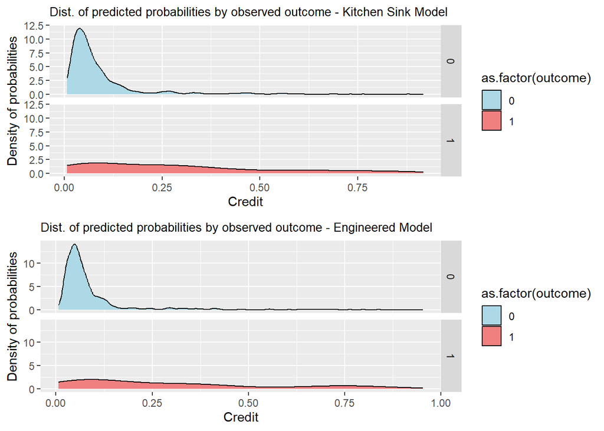

```r
# Creating probabilities plot for Base Model

a <- ggplot(kitchenSink_Test_Prob, aes(x = probs, fill = as.factor(outcome))) +
  geom_density() +
  facet_grid(outcome ~ .) +
  scale_fill_manual(values = palette2) +
  labs(x = "Credit", y = "Density of probabilities",
       title = "Dist. of predicted probabilities by observed outcome - Kitchen Sink Model") +
  theme(strip.text.x = element_text(size = 7), plot.title = element_text(size = 10))

# Creating probabilities plot for Engineered Model

b <- ggplot(housing_new_Test_Prob, aes(x = probs, fill = as.factor(outcome))) +
  geom_density() +
  facet_grid(outcome ~ .) +
  scale_fill_manual(values = palette2) +
  labs(x = "Credit", y = "Density of probabilities",
       title = "Dist. of predicted probabilities by observed outcome - Engineered Model") +
  theme(strip.text.x = element_text(size = 7), plot.title = element_text(size = 10))

ggarrange(a, b, nrow = 2)
```

### 4.3.2 CV Goodness of Fit

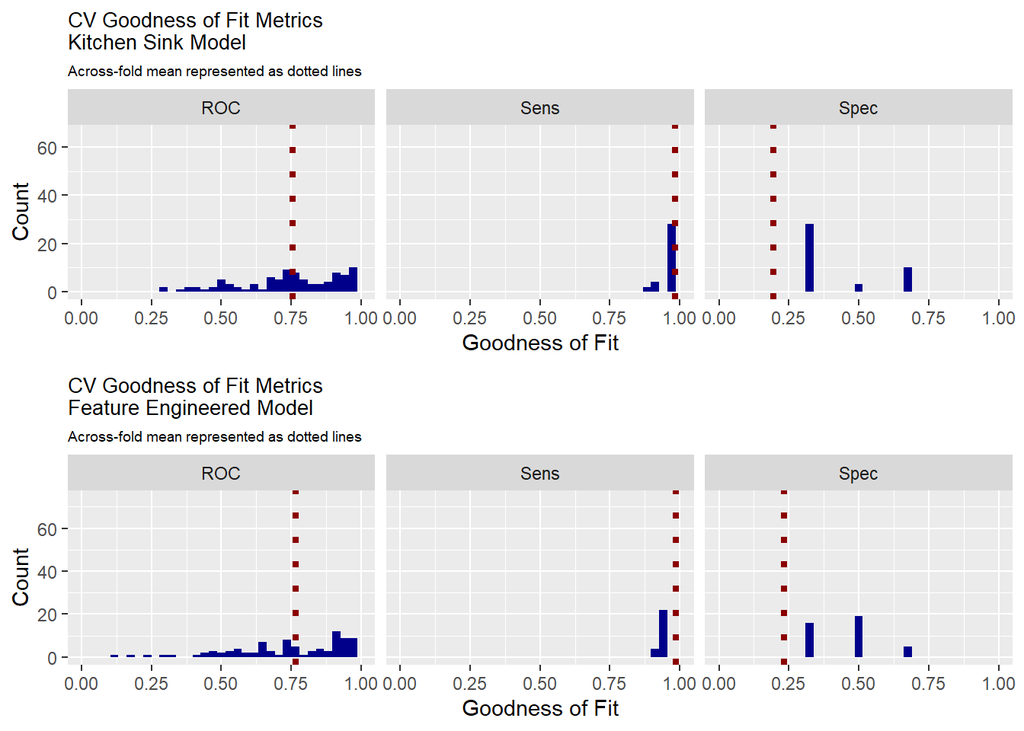

```r
# CV Goodness of Fit - Base Model

grid.arrange(ncol = 1,

  dplyr::select(cvFit_base$resample, -Resample) %>%
  gather(metric, value) %>%
  left_join(gather(cvFit_base$results[2:4], metric, mean)) %>%
  ggplot(aes(value)) +
  geom_histogram(bins=35, fill = "darkblue") +
  facet_wrap(~metric) +
  geom_vline(aes(xintercept = mean), colour = "darkred", linetype = 3, size = 1.5) +
  scale_x_continuous(limits = c(0, 1)) +
  labs(x="Goodness of Fit", y="Count", title="CV Goodness of Fit Metrics \nKitchen Sink Model",
       subtitle = "Across-fold mean represented as dotted lines") +
  theme(plot.title = element_text(size = 10), plot.subtitle = element_text(size = 7)),

# CV Goodness of Fit - Engineered Model

  dplyr::select(cvFit_new$resample, -Resample) %>%
  gather(metric, value) %>%
  left_join(gather(cvFit_new$results[2:4], metric, mean)) %>%
  ggplot(aes(value)) +
  geom_histogram(bins=35, fill = "darkblue") +
  facet_wrap(~metric) +
  geom_vline(aes(xintercept = mean), colour = "darkred", linetype = 3, size = 1.5) +
  scale_x_continuous(limits = c(0, 1)) +
  labs(x="Goodness of Fit", y="Count", title="CV Goodness of Fit Metrics \nFeature Engineered Model",
       subtitle = "Across-fold mean represented as dotted lines") +
  theme(plot.title = element_text(size = 10), plot.subtitle = element_text(size = 7)))
```

### 4.3.2 ROC Curve

In this comparison, the Base Model (AUC = 0.783) slightly outperforms the Engineered Model (AUC = 0.778), though the difference is minimal. Both models demonstrate a similar ability to distinguish between classes, with ROC curves that closely overlap. The nearly identical AUC values suggest that the feature engineering applied had little impact on overall model performance in this case.

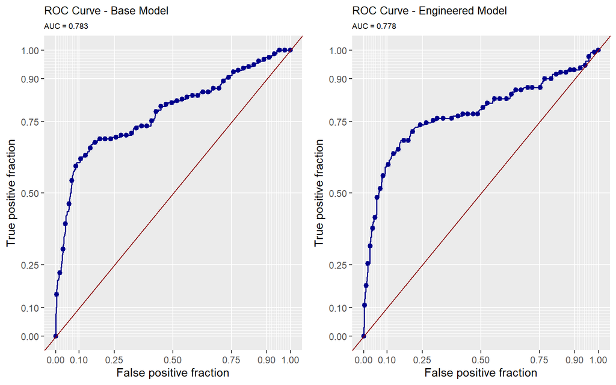

```r
# ROC Curve Plot - Base Model

a <- ggplot(kitchenSink_Test_Prob, aes(d = as.numeric(kitchenSink_Test_Prob$outcome), m = probs)) +
  geom_roc(n.cuts = 50, labels = FALSE, colour = "darkblue", size = .7) +
  style_roc(theme = theme_grey) +
  geom_abline(slope = 1, intercept = 0, size = .5, color = "darkred") +
  labs(title = "ROC Curve - Base Model", subtitle = "AUC = 0.783")+
  theme(plot.title = element_text(size = 10), plot.subtitle = element_text(size = 7))

# ROC Curve Plot - Engineered Model

b <- ggplot(housing_new_Test_Prob, aes(d = as.numeric(housing_new_Test_Prob$outcome), m = probs)) +
  geom_roc(n.cuts = 50, labels = FALSE, colour = "darkblue", size = .7) +
  style_roc(theme = theme_grey) +
  geom_abline(slope = 1, intercept = 0, size = .5, color = "darkred") +
  labs(title = "ROC Curve - Engineered Model", subtitle = "AUC = 0.778")+
  theme(plot.title = element_text(size = 10), plot.subtitle = element_text(size = 7))

ggarrange(a, b, nrow = 1)
```

# 5. Cost Benefit Analysiss

Assumptions:

1. The credit allocates `$5,000` per homeowner which can be used toward home improvement.
2. Houses that transacted after taking the credit, sold with a `$10,000` premium on average.
3. Homes surrounding the repaired home see an aggregate premium of `$56,000`, on average.
4. `25%` of people who enter the program ultimately use the credit

Based on these assumptions, the value of each home that enters the credit is `$66,000` without evaluating costs to the city

Cases:

1. True Positive: Assuming that 25% of people take a loan of $5000, we calculate net revenue as follows: Revenue = (Count * -2850) + 0.25 * Count * (-5000 + 10000 + 56000), where the formula includes both the credit and marketing costs incurred by the city in each case.
2. False Positive: For each false positive, there is a loss equivalent to the marketing costs allocated, leading to a revenue loss of $2850 per case.
3. True Negative: With no credit or marketing costs applied, there’s no revenue gain, totaling $0.
4. False Negative: A revenue gain of $0 is also assumed for false negatives, as the reasons participants may have taken credit are beyond the scope of the marketing campaign.

```r
# Cost Benefits Table - Base Model

cost_benefit_table_base <-
   kitchenSink_Test_Prob %>%
      count(pred_outcome, outcome) %>%
      summarize(True_Negative = sum(n[pred_outcome==0 & outcome==0]),
                True_Positive = sum(n[pred_outcome==1 & outcome==1]),
                False_Negative = sum(n[pred_outcome==0 & outcome==1]),
                False_Positive = sum(n[pred_outcome==1 & outcome==0])) %>%
       gather(Variable, Count) %>%
       mutate(Revenue =
               case_when(Variable == "True_Negative"  ~ Count * 0,
                         Variable == "True_Positive"  ~ ((Count * -2850) + (0.25 * Count * (-5000 + 10000 + 56000))),
                         Variable == "False_Negative" ~ Count * 0,
                         Variable == "False_Positive" ~ (Count * -2850))) %>%
    bind_cols(data.frame(Description = c(
              "Predicted correctly homeowner would not take the credit, no marketing resources were allocated, and no
              credit was allocated.",
              "Predicted correctly homeowner would take the credit; allocated the marketing resources, and 25% took
              the credit.",
              "We predicted that a homeowner would not take the credit but they did.",
              "Predicted incorrectly homeowner would take the credit; allocated marketing resources; no credit
              allocated.")))

kable(cost_benefit_table_base,
       caption = "Cost/Benefit Table - Base Data") %>% kable_styling()
```

Cost/Benefit Table - Base Data

| Variable | Count | Revenue | Description |
| --- | --- | --- | --- |
| True_Negative | 1267 | 0 | Predicted correctly homeowner would not take the credit, no marketing resources were allocated, and no credit was allocated. |
| True_Positive | 32 | 396800 | Predicted correctly homeowner would take the credit; allocated the marketing resources, and 25% took the credit. |
| False_Negative | 126 | 0 | We predicted that a homeowner would not take the credit but they did. |
| False_Positive | 17 | -48450 | Predicted incorrectly homeowner would take the credit; allocated marketing resources; no credit allocated. |

```r
# Cost Benefits Table - Engineered Model

cost_benefit_table_new <-
   housing_new_Test_Prob %>%
      count(pred_outcome, outcome) %>%
      summarize(True_Negative = sum(n[pred_outcome==0 & outcome==0]),
                True_Positive = sum(n[pred_outcome==1 & outcome==1]),
                False_Negative = sum(n[pred_outcome==0 & outcome==1]),
                False_Positive = sum(n[pred_outcome==1 & outcome==0])) %>%
       gather(Variable, Count) %>%
       mutate(Revenue =
               case_when(Variable == "True_Negative"  ~ Count * 0,
                         Variable == "True_Positive"  ~ ((Count * -2850) + (0.25 * Count * (-5000 + 10000 + 56000))),
                         Variable == "False_Negative" ~ Count * 0,
                         Variable == "False_Positive" ~ (Count * -2850))) %>%
    bind_cols(data.frame(Description = c(
              "Predicted correctly homeowner would not take the credit, no marketing resources were allocated, and no
              credit was allocated.",
              "Predicted correctly homeowner would take the credit; allocated the marketing resources, and 25% took
              the credit.",
              "We predicted that a homeowner would not take the credit but they did.",
              "Predicted incorrectly homeowner would take the credit; allocated marketing resources; no credit
              allocated.")))

kable(cost_benefit_table_new,
       caption = "Cost/Benefit Table - Engineered Data") %>% kable_styling()
```

Cost/Benefit Table - Engineered Data

| Variable | Count | Revenue | Description |
| --- | --- | --- | --- |
| True_Negative | 1053 | 0 | Predicted correctly homeowner would not take the credit, no marketing resources were allocated, and no credit was allocated. |
| True_Positive | 28 | 347200 | Predicted correctly homeowner would take the credit; allocated the marketing resources, and 25% took the credit. |
| False_Negative | 102 | 0 | We predicted that a homeowner would not take the credit but they did. |
| False_Positive | 17 | -48450 | Predicted incorrectly homeowner would take the credit; allocated marketing resources; no credit allocated. |

```r
# Thresholds function - Base Model

iterateThresholds_base <- function(data) {
  x = .01
  all_prediction <- data.frame()
  while (x <= 1) {

  this_prediction <-
      kitchenSink_Test_Prob %>%
      mutate(pred_outcome = ifelse(probs > x, 1, 0)) %>%
      count(pred_outcome, outcome) %>%
      summarize(True_Negative = sum(n[pred_outcome==0 & outcome==0]),
                True_Positive = sum(n[pred_outcome==1 & outcome==1]),
                False_Negative = sum(n[pred_outcome==0 & outcome==1]),
                False_Positive = sum(n[pred_outcome==1 & outcome==0])) %>%
     gather(Variable, Count) %>%
     mutate(Revenue =
               ifelse(Variable == "True_Negative", (Count * 0),
               ifelse(Variable == "True_Positive", ((Count * -2850) + (0.25 * Count * (-5000 + 10000 + 56000))),
               ifelse(Variable == "False_Negative", (Count * 0),
               ifelse(Variable == "False_Positive", (Count * -2850), 0
                      )
               )
               )
               ),
            Threshold = x)

  all_prediction <- rbind(all_prediction, this_prediction)
  x <- x + .01
  }
return(all_prediction)
}

# Thresholds function - Engineered Model

iterateThresholds_new <- function(data) {
  x = .01
  all_prediction <- data.frame()
  while (x <= 1) {

  this_prediction <-
      housing_new_Test_Prob %>%
      mutate(pred_outcome = ifelse(probs > x, 1, 0)) %>%
      count(pred_outcome, outcome) %>%
      summarize(True_Negative = sum(n[pred_outcome==0 & outcome==0]),
                True_Positive = sum(n[pred_outcome==1 & outcome==1]),
                False_Negative = sum(n[pred_outcome==0 & outcome==1]),
                False_Positive = sum(n[pred_outcome==1 & outcome==0])) %>%
     gather(Variable, Count) %>%
     mutate(Revenue =
               ifelse(Variable == "True_Negative", (Count * 0),
               ifelse(Variable == "True_Positive", ((Count * -2850) + (0.25 * Count * (-5000 + 10000 + 56000))),
               ifelse(Variable == "False_Negative", (Count * 0),
               ifelse(Variable == "False_Positive", (Count * -2850), 0
                      )
               )
               )
               ),
            Threshold = x)

  all_prediction <- rbind(all_prediction, this_prediction)
  x <- x + .01
  }
return(all_prediction)
}
```

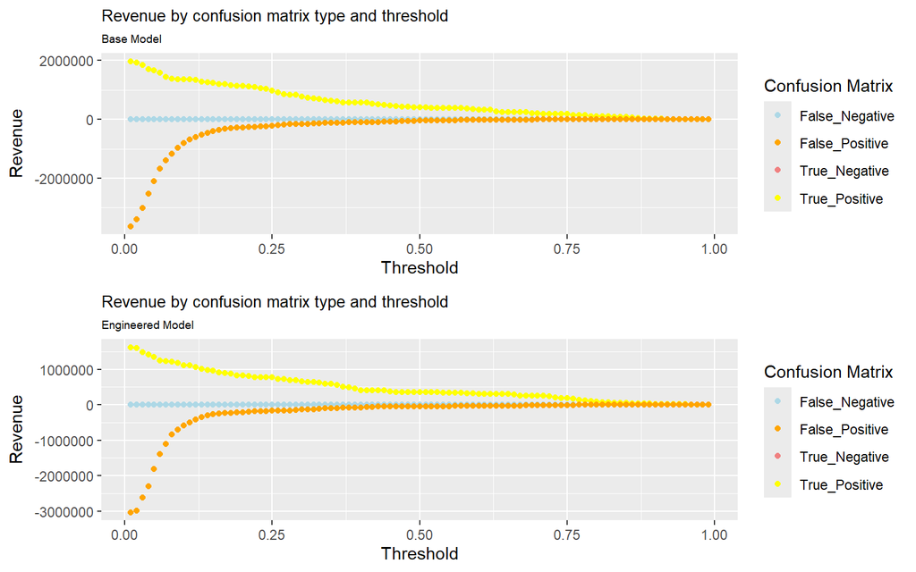

```r
# Confusion Matrix - Base Model Threshold

baseThreshold <- iterateThresholds_base(kitchenSink_Test_Prob)

baseThreshold_revenue <-
baseThreshold %>%
    group_by(Threshold) %>%
    summarize(Revenue = sum(Revenue))

a <- baseThreshold %>%
  ggplot(.,aes(Threshold, Revenue, colour = Variable)) +
  geom_point() +
  scale_colour_manual(values = palette4) +
  labs(title = "Revenue by confusion matrix type and threshold", subtitle = "Base Model",
       y = "Revenue") + theme(plot.title = element_text(size = 10), plot.subtitle = element_text(size = 7)) +
  guides(colour=guide_legend(title = "Confusion Matrix"))

# Confusion Matrix - Engineered Model Threshold

engineeredThreshold <- iterateThresholds_new(housing_new_Test_Prob)

engineeredThreshold_revenue <-
engineeredThreshold %>%
    group_by(Threshold) %>%
    summarize(Revenue = sum(Revenue))

b <- engineeredThreshold %>%
  ggplot(.,aes(Threshold, Revenue, colour = Variable)) +
  geom_point() +
  scale_colour_manual(values = palette4) +
  labs(title = "Revenue by confusion matrix type and threshold", subtitle = "Engineered Model",
       y = "Revenue") + theme(plot.title = element_text(size = 10), plot.subtitle = element_text(size = 7)) +
  guides(colour=guide_legend(title = "Confusion Matrix"))

ggarrange(a,b, nrow=2)
```

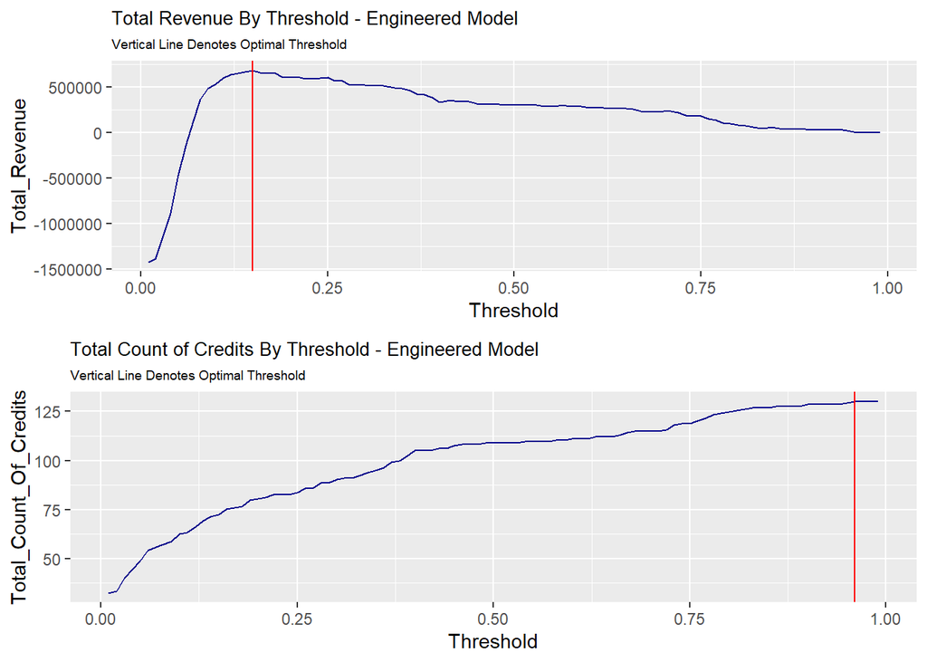

```r
# Revenue and Credits by Threshold for Base Model

baseThreshold_revenue <-
  baseThreshold %>%
    mutate(TookCredit = ifelse(Variable == "True_Positive", (Count * .25),
                         ifelse(Variable == "False_Negative", Count, 0))) %>%
  group_by(Threshold) %>%
    summarize(Total_Revenue = sum(Revenue),
              Total_Count_Of_Credits = sum(TookCredit))

# Revenue and Credits by Threshold for Engineered Model

engineeredThreshold_revenue <-
  engineeredThreshold %>%
    mutate(TookCredit = ifelse(Variable == "True_Positive", (Count * .25),
                         ifelse(Variable == "False_Negative", Count, 0))) %>%
  group_by(Threshold) %>%
    summarize(Total_Revenue = sum(Revenue),
              Total_Count_Of_Credits = sum(TookCredit))

# Revenue Plot for Engineered Model
grid.arrange(ncol = 1,
ggplot(engineeredThreshold_revenue)+
  geom_line(aes(x = Threshold, y = Total_Revenue),color = "darkblue")+
  geom_vline(xintercept =  pull(arrange(engineeredThreshold_revenue, -Total_Revenue)[1,1]),color = "red")+
    labs(title = "Total Revenue By Threshold - Engineered Model",
         subtitle = "Vertical Line Denotes Optimal Threshold")+
  theme(plot.title = element_text(size = 10), plot.subtitle = element_text(size = 7)),

# Credits Plot for Engineered Model
ggplot(engineeredThreshold_revenue)+
  geom_line(aes(x = Threshold, y = Total_Count_Of_Credits),color = "darkblue")+
  geom_vline(xintercept =  pull(arrange(engineeredThreshold_revenue, -Total_Count_Of_Credits)[1,1]),color = "red")+
    labs(title = "Total Count of Credits By Threshold - Engineered Model",
         subtitle = "Vertical Line Denotes Optimal Threshold") +
  theme(plot.title = element_text(size = 10), plot.subtitle = element_text(size = 7)))
```

```r
# Optimal Threshold - Base Model

optimalthreshold_base <-
  baseThreshold_revenue %>%
  dplyr::select(Threshold, Total_Revenue, Total_Count_Of_Credits)%>%
  mutate(Model = "Base Model")

optimalthreshold_base_table <-
  baseThreshold_revenue %>%
  dplyr::select(Threshold, Total_Revenue, Total_Count_Of_Credits)

optimalthreshold_base_table <- optimalthreshold_base %>%
  filter(row_number() %in% c(20, 50))

# Optimal Threshold - Engineered Model

optimalthreshold_new <-
  engineeredThreshold_revenue %>%
  dplyr::select(Threshold, Total_Revenue, Total_Count_Of_Credits)%>%
  mutate(Model = "Engineered Model")

optimalthreshold_new_table <-
  engineeredThreshold_revenue %>%
  dplyr::select(Threshold, Total_Revenue, Total_Count_Of_Credits)

optimalthreshold_new_table <- optimalthreshold_new %>%
  filter(row_number() %in% c(17, 50))

optimalthreshold_table <- rbind(optimalthreshold_base_table, optimalthreshold_new_table) %>%
  select(Threshold, Model, Total_Revenue, Total_Count_Of_Credits)

kable(optimalthreshold_table, caption = "
      Cost/Benefit Table") %>% kable_styling()
```

Cost/Benefit Table

| Threshold | Model | Total_Revenue | Total_Count_Of_Credits |
| --- | --- | --- | --- |
| 0.20 | Base Model | 854800 | 89.75 |
| 0.50 | Base Model | 348350 | 134.00 |
| 0.17 | Engineered Model | 650550 | 76.00 |
| 0.50 | Engineered Model | 298750 | 109.00 |

# 6. Conclusion

In conclusion, it is not advisable to put this model into production, as the performance of the feature-engineered model in regression did not show significant improvement and resulted in relatively lower income levels. A more thorough analysis of the feature engineering process is necessary, along with the introduction of additional relevant variables to enable more scientific and accurate predictions. By integrating more data and features, we can enhance the model’s predictive capability, ultimately leading to more effective decision-making support.

The following qualitative and quantitative factors which are missing in the current dataset may merit consideration.

### Financial Characteristics:

1. **Income**: Homeowners with lower incomes are more likely to utilize tax credits for home repairs.
2. **Property Value**: The homeowner’s decision may be influenced by property value, especially if the tax credit is based on the property’s worth.

### Spatial Factors:

1. **Neighborhood Characteristics**: The economic status and development level of the neighborhood can impact homeowners’ choices.
2. **Crime Statistics**: The level of crime may affect a homeowner’s willingness to maintain their property.
3. **Participation Mapping**: Highlighting neighborhoods where homes have participated in the program before is useful, although the impact of ‘word of mouth’ through social networks is difficult to measure and not captured in the current model.

By adopting a continuously iterative approach that merges financial and spatial aspects, Emil City can create a more targeted, proactive, and effective model to achieve its goal of safe homes and vibrant communities.